# Wizualizacja parametrów meteorologicznych i hydrologicznych w raportach ZMŚP

XXXII Ogólnopolska Szkoła ZMŚP · 23–24 września 2026

Anna Dmowska, Robert Kruszyk, Mikołaj Majewski, Krzysztof Klincewicz, Natalia Wróbel

## Typy wykresów

**A1 — meteorologia: 30 rycin** · **H1 — hydrologia: 11 rycin** · **H1 — hydrochemia: 6 rycin**

[figure not shown]

## Typy wykresów — hydrochemia

**Ryciny 12–17 raportu H1** · sześć typów, których nie ma w pozostałych programach

[figure not shown]

## Typy wykresów

## Wykres słupkowy odchyleń

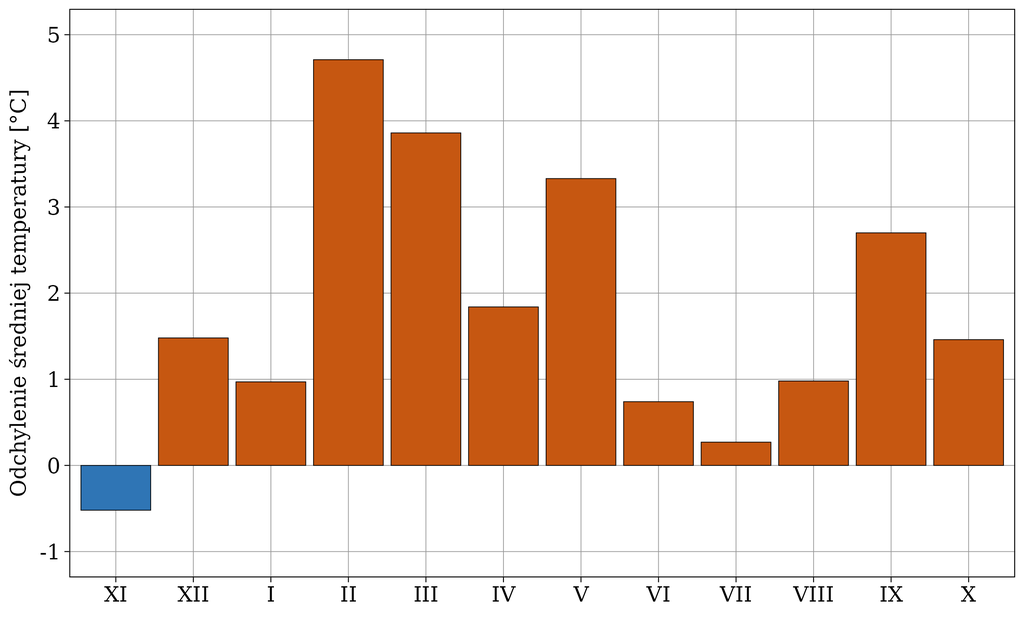

Odchylenia średniej miesięcznej temperatury powietrza od średniej wieloletniej *(ryciny 7, 8, 18, 19)*

Słupki wyrastają w górę albo w dół od linii zera. **Zero to nie brak zjawiska, tylko zgodność ze średnią wieloletnią.**

- Słupek **w górę** — w tym miesiącu (roku) było **więcej** niż przeciętnie: cieplej albo więcej opadu.
- Słupek **w dół** — było **mniej**: chłodniej albo sucho.
- **Wysokość słupka** mówi, o ile: dla temperatury w stopniach, dla opadu w milimetrach.

Kolory tylko powtarzają kierunek odchylenia (dodatnie / ujemne) — nie niosą osobnej informacji.

Najcieplejszym miesiącem w odniesieniu do wielolecia był luty (+4,7°C), a jedynym chłodniejszym od średniej — listopad (−0,5°C).

Występuje tylko w A1 — ryciny 7, 8, 18 i 19.

## Wykres wstęgowy

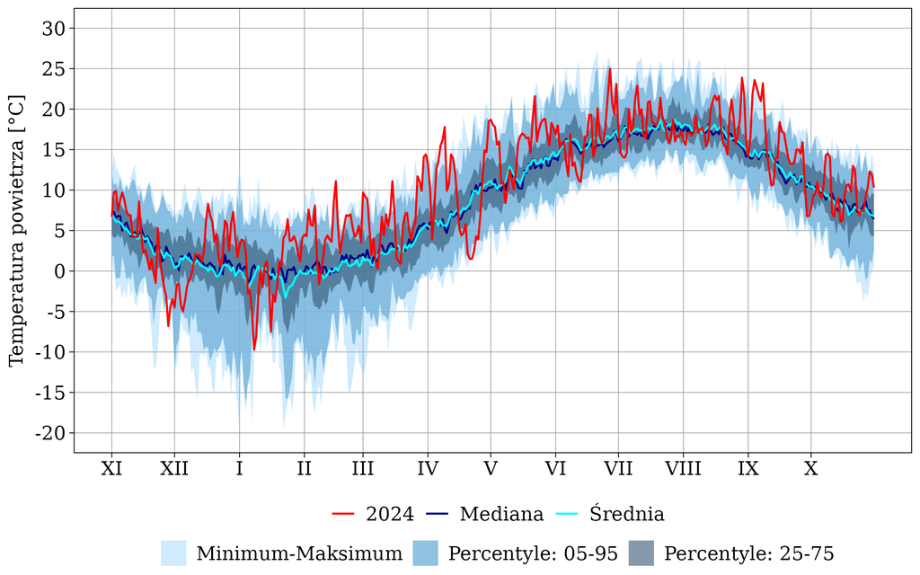

Przebieg roku analizowanego na tle statystyk wielolecia *(ryciny 10–14)*

Wstęgi to „obwiednia” wielolecia: dla **każdego dnia roku** policzono, jakie wartości notowano tego dnia we wszystkich latach wielolecia.

| Element ryciny | Co oznacza |
| --- | --- |
| najjaśniejszy, najszerszy pas | **minimum–maksimum**: skrajne wartości notowane tego dnia w całym wieloleciu |
| pas średni | **percentyle 5–95**: 90% lat mieściło się w tym zakresie |
| pas najciemniejszy | **percentyle 25–75**: połowa lat — „strefa typowa” |
| granatowa linia | **mediana** wielolecia dla danego dnia |
| jasnoniebieska linia | **średnia** wielolecia dla danego dnia |
| **czerwona linia** | **rok analizowany** |

## Wykres wstęgowy: temperatura powietrza (A1)

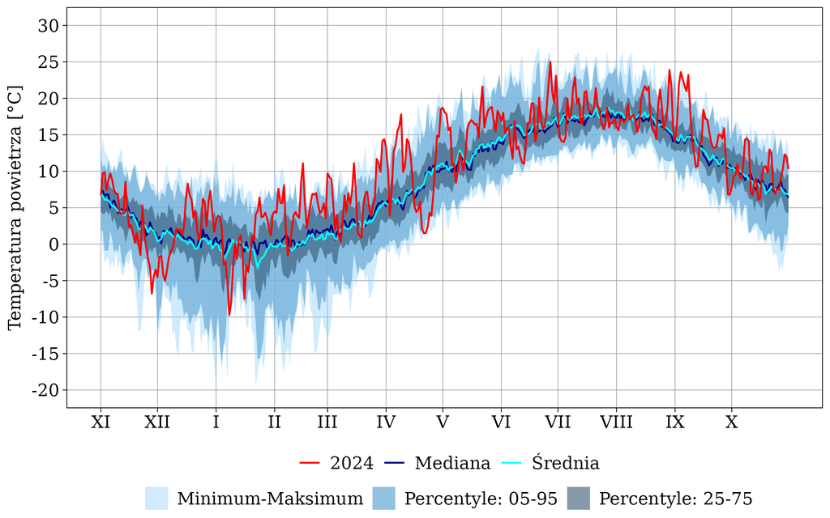

Czytasz to jednym spojrzeniem: **gdzie biegnie czerwona linia względem pasów**.

- **Wewnątrz najciemniejszego pasa** — dzień typowy, nic nadzwyczajnego.
- **Poza pasem percentyli 5–95**, ale w obrębie minimum–maksimum — wartość rzadka, choć notowana już wcześniej.
- **Poza najjaśniejszym pasem** — wartość, jakiej w tym dniu roku nie notowano w całym wieloleciu. To jest coś, co warto opisać.

## Wykres wstęgowy: natężenie przepływu (H1)

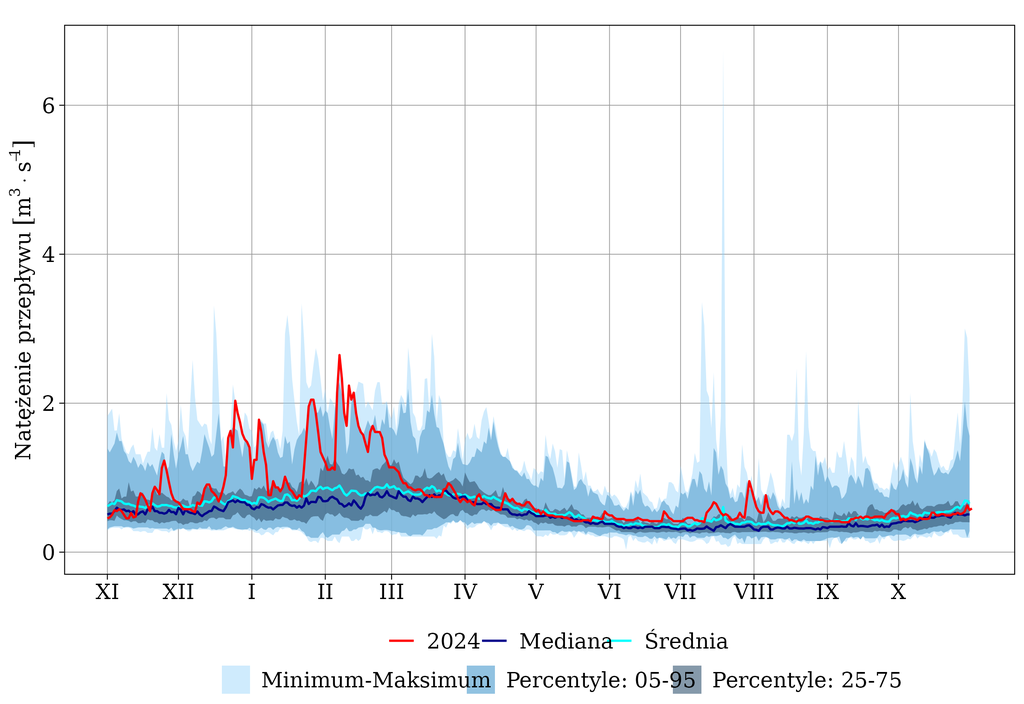

Przepływ w kolejnych dniach roku na tle zmienności wielolecia *(rycina 3)*

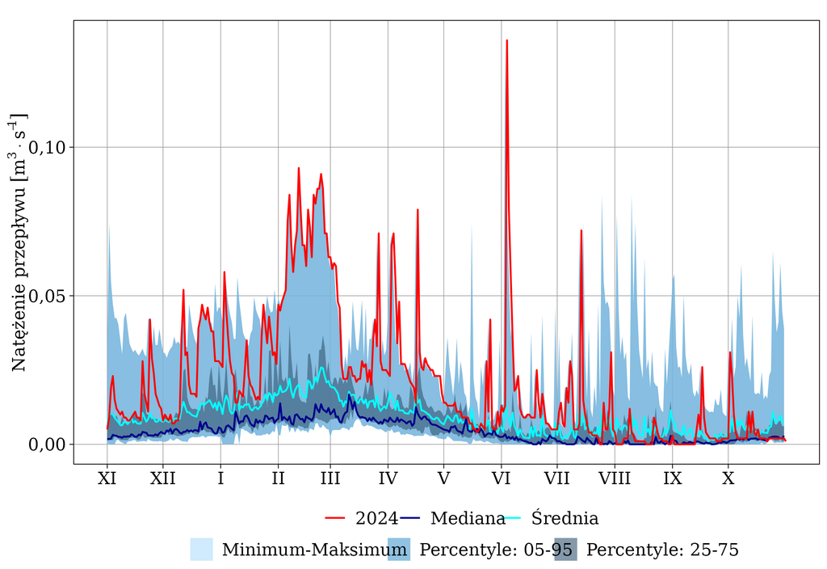

Inna stacja, **krótsze wielolecie** — wstęgi są węższe i bardziej poszarpane

Im krótsze wielolecie, tym węższa wstęga i tym łatwiej z niej wyjść — sprawdź w podpisie ryciny, ile lat ją tworzy.

## Wykres pudełkowy: temperatura powietrza (A1)

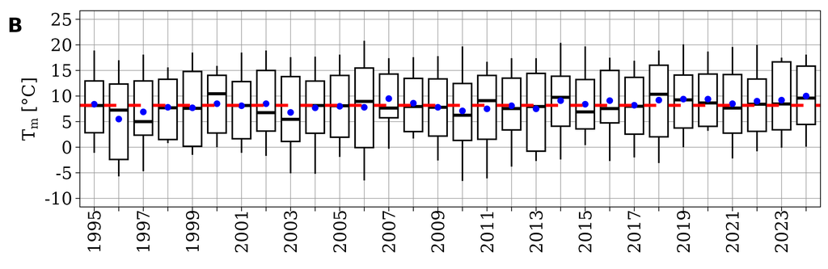

Zmienność miesięcznych wartości temperatury w kolejnych latach *(ryciny 15B i 16B)*

Boxplot pokazuje **rozrzut** wielu wartości naraz — u nas dwunastu wartości miesięcznych w obrębie jednego roku. **Jedno pudełko = jeden rok.**

- **Linia w środku pudełka to mediana** — wartość środkowa. Połowa miesięcy miała wartość wyższą, połowa niższą.
- **Pudełko obejmuje połowę danych** — od 25% do 75%. Im **wyższe pudełko**, tym bardziej miesiące różniły się między sobą.
- **Wąsy** to zasięg pozostałych typowych wartości.
- **Punkty poza wąsami** to wartości nietypowe — miesiąc wyraźnie odstający od reszty roku.

## Wykres pudełkowy: opad atmosferyczny (A1)

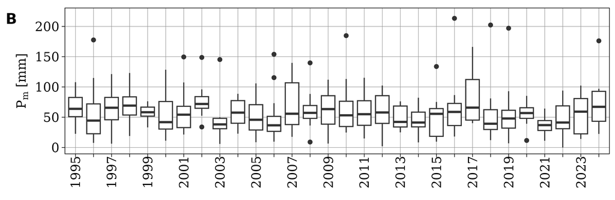

Czytasz tak samo jak boxplot temperaturowy, ale zwracasz uwagę na inne rzeczy:

- **wysokie pudełko** — rok kontrastowy, kilka miesięcy mokrych obok suchych,
- **niskie pudełko** — rok wyrównany, opad rozłożony równomiernie,
- **punkty odstające** — miesiąc z opadem znacznie wyższym niż pozostałe.

Przy opadach rozrzut jest z natury większy niż przy temperaturze, więc wysokie pudełka są tu regułą, a nie wyjątkiem.

## Wykres pudełkowy: natężenie przepływu (H1)

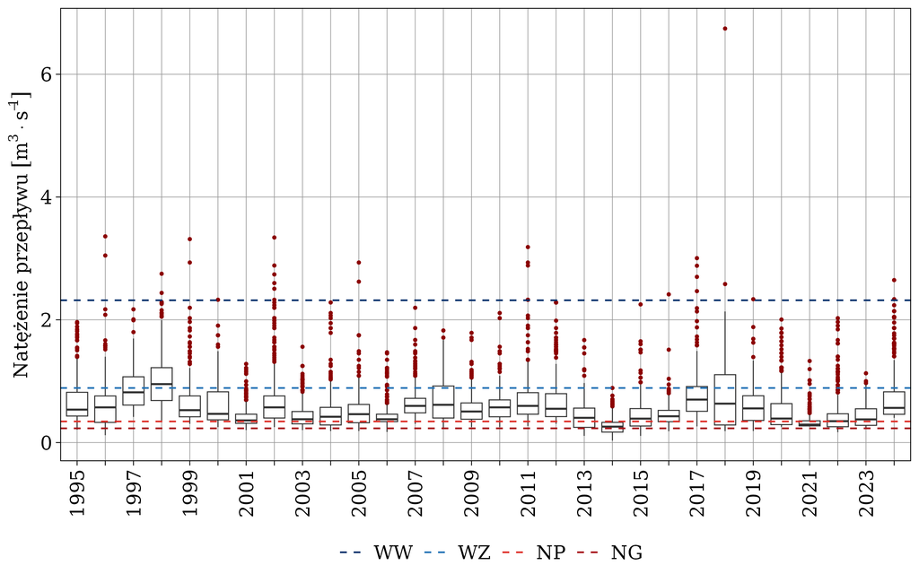

- **Wysokie pudełko** — rok, w którym przepływ zmieniał się w szerokim zakresie
- **Niskie pudełko** — rok wyrównany
- **Dużo punktów u góry** — to normalne w hydrologii: wezbrania z definicji są rzadkie i wysokie, więc wypadają poza wąsy

Kiedy dokładnie wystąpiło wezbranie, powie rycina 2.

## Wykresy kafelkowe (mapy ciepła)

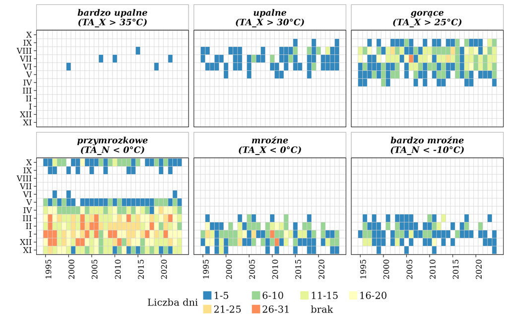

Liczba dni charakterystycznych w układzie rok × miesiąc *(ryciny 27–30)*

Kolorowe kwadraty w układzie **rok × miesiąc** albo **rok × element**. Czytasz je jak tabelę: pozycja mówi, którego okresu dotyczy kafelek, a kolor — jaka jest wartość. Skala kolorów jest zawsze wyjaśniona w legendzie pod ryciną.

Szukaj **wzorów, a nie pojedynczych kafelków**:

- **pionowe pasy** — cały rok odstający,
- **poziome pasy** — jeden miesiąc odstający we wszystkich latach,
- **stopniowa zmiana barwy** od lewej do prawej — zmiana w czasie.

## Wykres kafelkowy: opad atmosferyczny (H1)

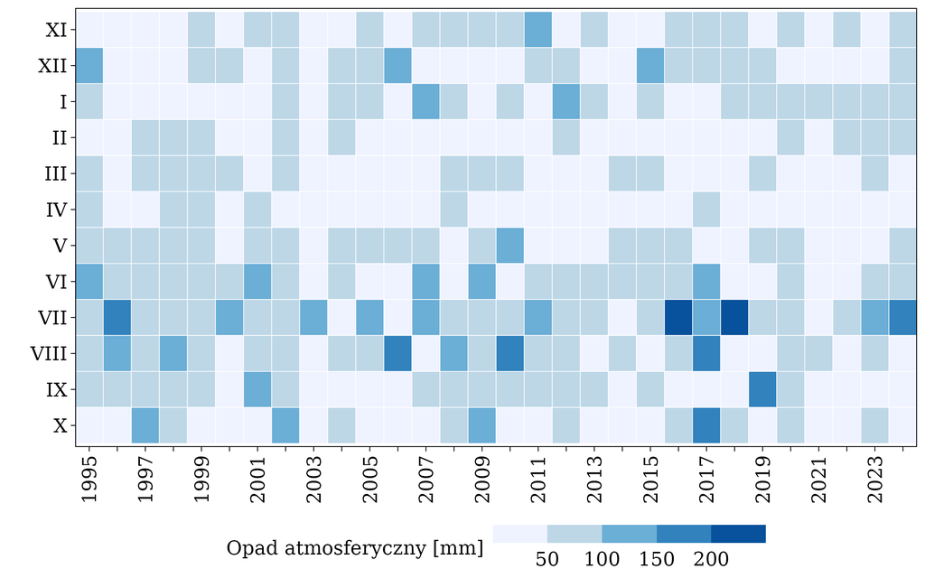

Miesięczne sumy opadu w kolejnych latach *(rycina 4)*

Siatka **rok × miesiąc**, w której barwa kafelka niesie wartość.

Szukaj wzorów, nie pojedynczych kafelków

- **pionowy pas** jednego koloru — rok odstający
- **poziomy pas** — miesiąc, który wypada podobnie we wszystkich latach
- **biały kafelek** — brak pomiaru; podpis ryciny mówi, czy chodzi o brak danych, czy o brak zjawiska

Liczb się z niej nie odczytuje — od tego są tabele.

## Wykres kafelkowy: kategorie i kompletność (H1)

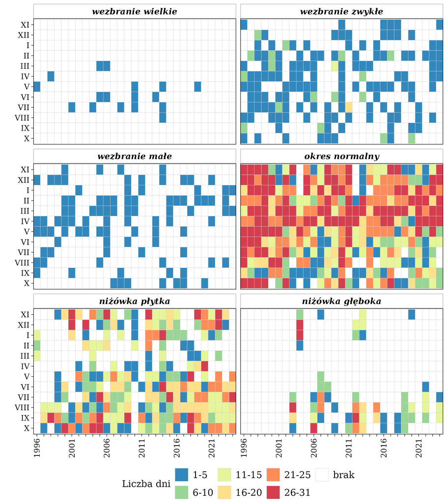

**Rycina 6** — liczba dni w kategoriach przepływu, panel na kategorię

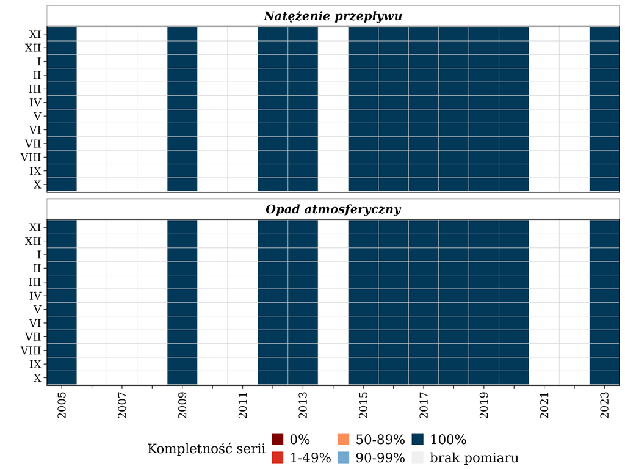

**Rycina 11** — kompletność serii: barwa niesie **jakość danych**, nie wartość. Ciepłe barwy to serie zbyt niepełne; **szary kafelek to brak serii**, nie zero pomiarów.

## Słupkowy struktury: kategorie przepływu (H1)

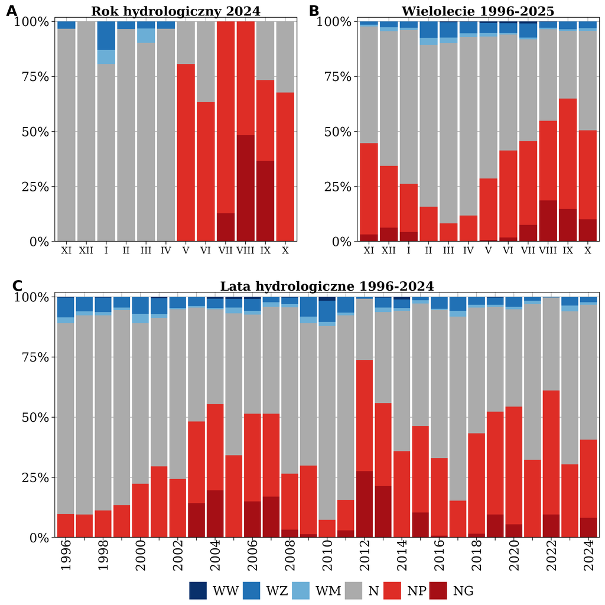

Udziały kategorii przepływu: miesiące roku (A), miesiące wielolecia (B), kolejne lata (C) *(rycina 5)*

Każdy słupek ma **tę samą wysokość**, bo pokazuje udziały sumujące się do 100%.

Czytasz proporcje, nie liczbę dni

Barwy porządkują odczyt: **odcienie niebieskiego to wezbrania**, szary to okres normalny, **odcienie czerwieni to niżówki**. Dzięki stałej wysokości słupków od razu widać, w którym miesiącu albo roku przeważały jedne, a w którym drugie. **Liczby dni** są na rycinie 6 i w tabeli 4.

## Słupkowy struktury: dni charakterystyczne (A1)

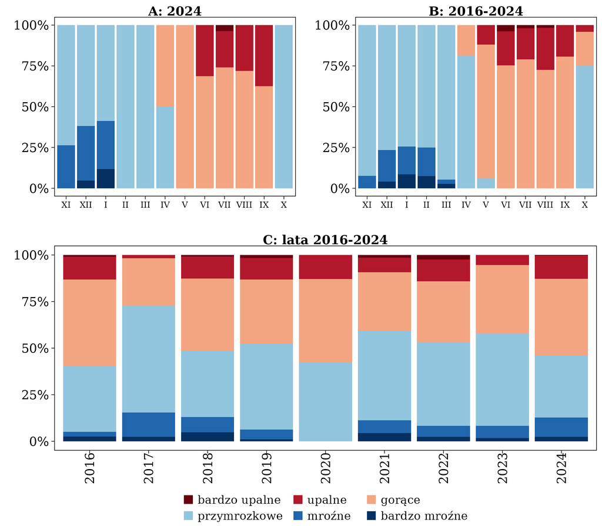

Udziały dni charakterystycznych termicznych w kolejnych latach *(rycina 25)*

Ten sam typ na danych meteorologicznych. **W programie A1 są dwie takie ryciny**: rycina 25 dla dni charakterystycznych **termicznych** i rycina 26 dla **opadowych**.

Czytasz je identycznie jak rycinę H1: słupki mają **stałą wysokość**, więc porównujesz **proporcje**, a nie liczby dni. Liczby dni znajdziesz w tabeli 8.

## Punktowy z linią trendu — tylko w A1

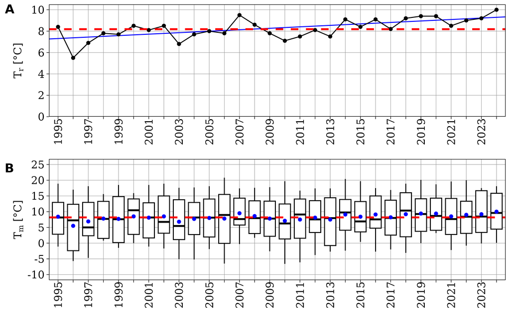

Średnia roczna temperatura powietrza z linią trendu (A) oraz zmienność wartości miesięcznych (B)

Jedna rycina, **dwa różne pytania**.

- **Panel A** — czy w kolejnych latach jest cieplej? Odpowiada na to linia trendu.
- **Panel B** — jak bardzo miesiące różniły się w obrębie każdego roku? Odpowiada na to boxplot.

Oba panele omawiamy osobno na kolejnych slajdach.

## Linia trendu — jak czytać

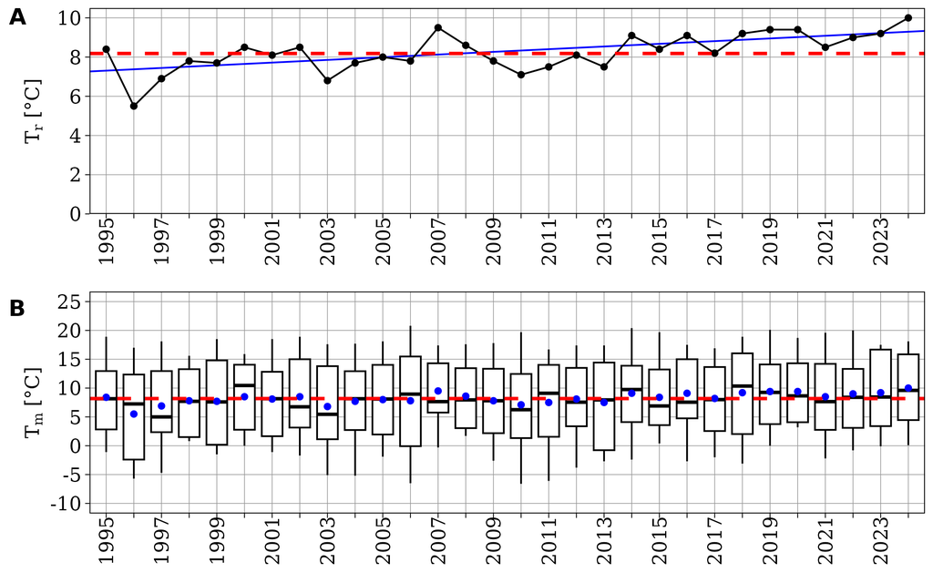

Niebieska prosta pokazuje, czy temperatura w kolejnych latach systematycznie rośnie albo maleje. Wyznaczono ją **metodą Theila-Sena**, odporną na pojedyncze nietypowe lata i na luki w serii.

W podpisie ryciny podane są dwie liczby:

- **nachylenie (slope)** — o ile stopni zmienia się temperatura **w ciągu roku**. Wartość 0,0684 °C/rok oznacza wzrost o ok. **0,7 °C na dekadę** (mnożysz przez 10).
- **poziom istotności (p)** — jak pewny jest ten wynik:

| `p` | Sformułowanie do raportu |
| --- | --- |
| < 0,001 | trend istotny statystycznie |
| < 0,05 | trend istotny statystycznie |
| ≥ 0,05 | tendencja **nieistotna** statystycznie |

## Linia trendu — o czym pamiętać

Gdy `p` jest większe lub równe 0,05, **nie pisz** „temperatura wzrosła o…“.

Napisz, że zaznacza się **tendencja** wzrostowa, ale przy tej długości serii nie jest ona istotna statystycznie. Nachylenie linii samo w sobie nie dowodzi zmiany.

Jeśli seria ma **mniej niż 5 lat** z pomiarem, linii w ogóle nie ma, a podpis ryciny mówi o tym wprost.

## H1: wody powierzchniowe

## Opad i przepływ dzień po dniu

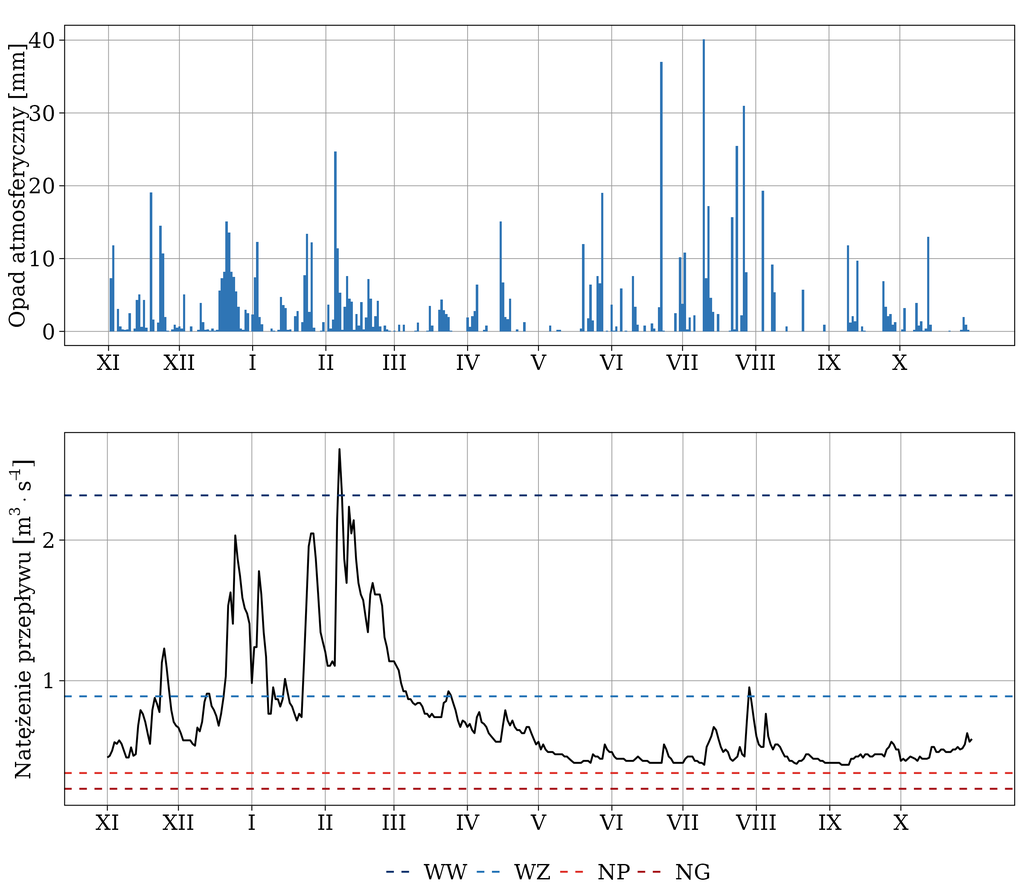

Dobowe wartości opadu i natężenia przepływu w roku analizowanym *(rycina 2)*

Dwa panele, wspólna oś czasu obejmująca cały rok hydrologiczny:

- **u góry** dobowe sumy opadu — zwykłe słupki
- **pod spodem** dobowy przepływ linią, z liniami granicznymi kategorii

Najlepsze źródło konkretnych dat do komentarza

Szukaj **reakcji zlewni**: ile dni mija między opadem a wzrostem przepływu i czy każdy opad taką reakcję wywołuje.

## Opad i odpływ

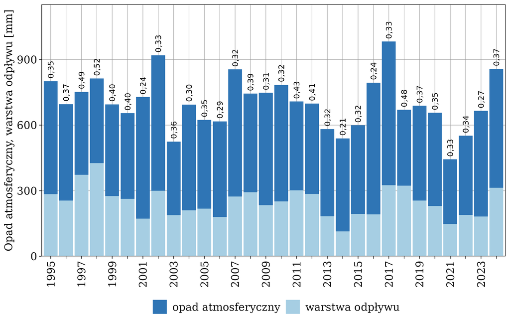

Roczne sumy opadu i warstwy odpływu, nad słupkami współczynnik odpływu *(rycina 7)*

Na każdy rok jeden słupek **wpisany w drugi**: ciemniejszy to suma opadu, jaśniejszy — warstwa odpływu, czyli ta część opadu, która ze zlewni odpłynęła. Nad słupkiem stoi **współczynnik odpływu**.

Im mniejsza różnica między słupkami, tym większa część opadu zamieniła się w odpływ. Wartość 0,30 oznacza, że odpłynęło 30% tego, co spadło.

Wartość powyżej 1 nie jest błędem: zlewnia mogła oddać wodę zgromadzoną wcześniej, np. z roztopów albo z zasilania podziemnego.

## Współczynnik odpływu

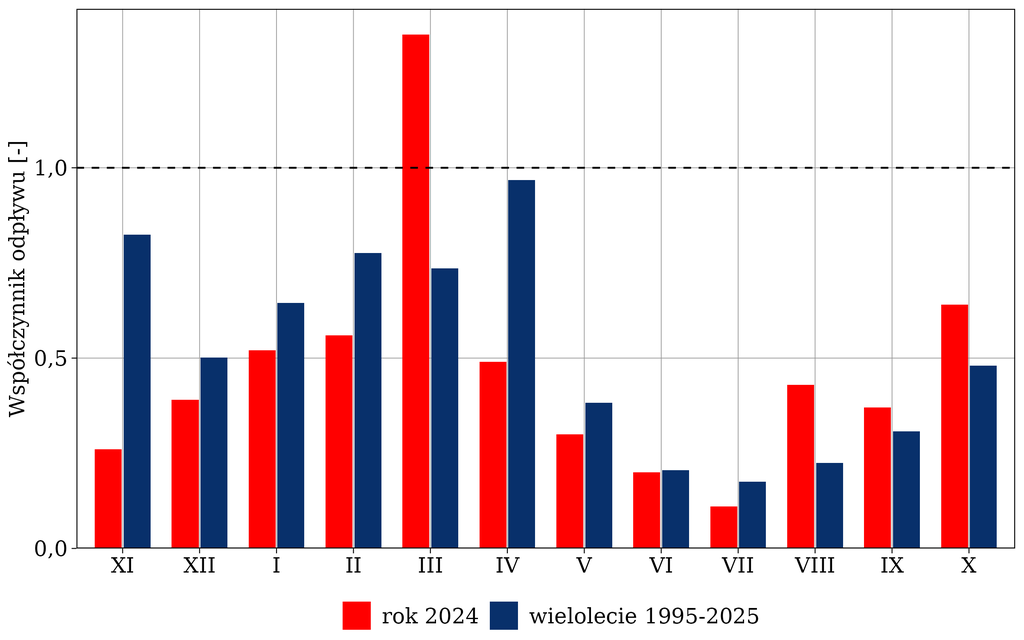

Miesięczne wartości współczynnika odpływu *(rycina 8)*

Współczynnik odpływu to **iloraz warstwy odpływu i opadu** (α = O / P). Mówi, jaka część opadu odpłynęła ciekiem ze zlewni.

Słupki są zestawione **parami**: rok analizowany obok wartości wieloletniej tego samego miesiąca.

- **powyżej 1** — odpłynęło więcej, niż spadło w tym miesiącu
- **poniżej 1** — część opadu została w zlewni

Metodyka nie przewiduje liczenia współczynnika w przedziałach dobowych — czas reakcji zlewni na opad jest dłuższy niż doba. Sensowne są dopiero wartości miesięczne, półroczne i roczne.

## Współczynnik natężenia przepływu

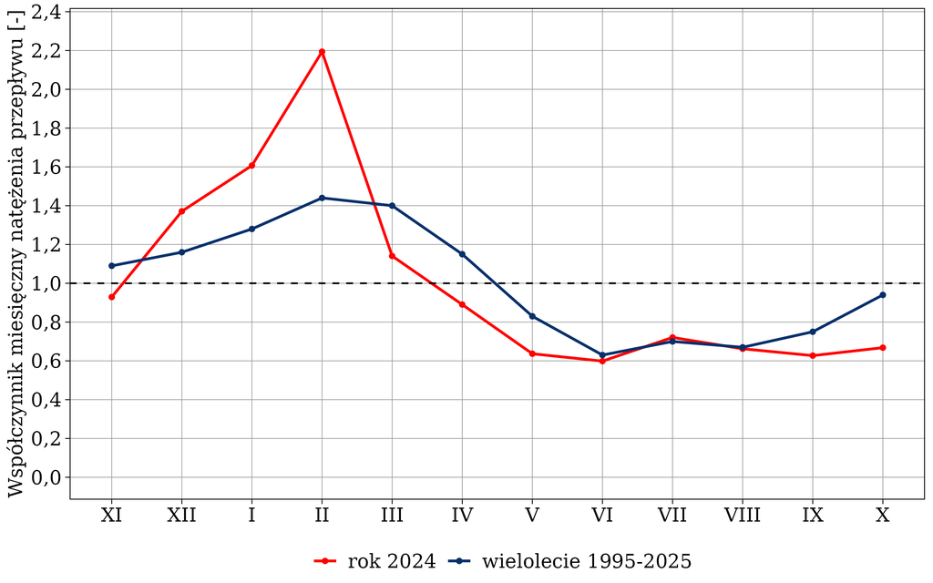

Miesięczny współczynnik natężenia przepływu na tle wartości wieloletnich *(rycina 10)*

- **powyżej 1** — miesiąc z przepływami wyższymi od średniej rocznej; według metodyki to miesiąc, w którym pojawiają się wezbrania
- **poniżej 1** — miesiąc z przepływami niższymi od średniej rocznej

Dwanaście wartości tworzy obraz ustroju rzecznego zlewni

## Zmienność amplitud

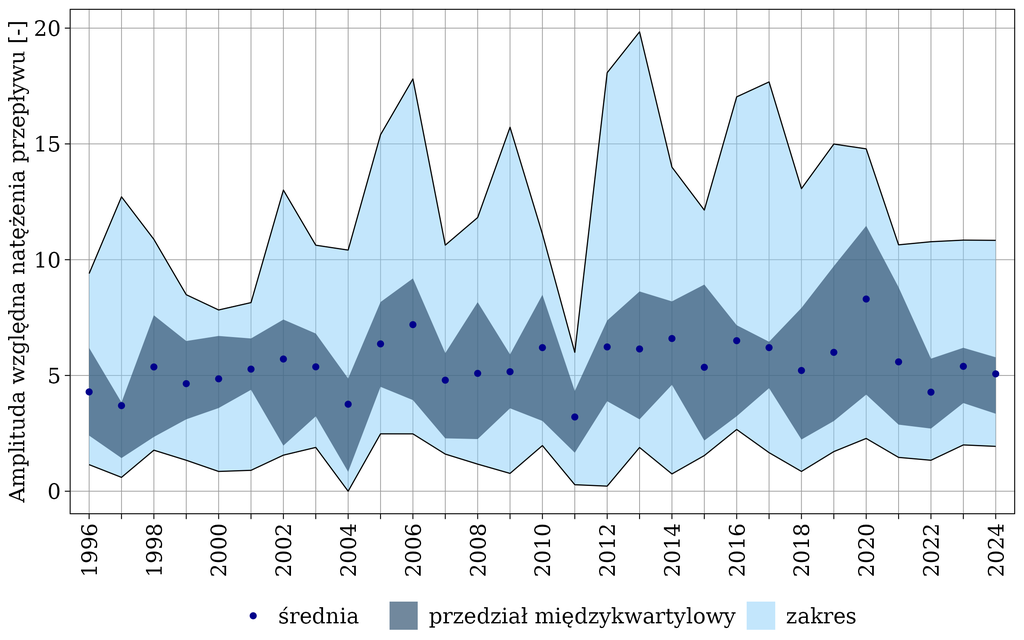

Zmienność miesięcznych wartości amplitudy względnej przepływu *(rycina 9)*

Amplituda względna to **(WQ − NQ) / SQ** — różnica między przepływem maksymalnym a minimalnym, odniesiona do średniego. Mówi, jak bardzo przepływ zmieniał się w obrębie miesiąca.

Każdy rok opisują trzy wielkości policzone z jego **dwunastu wartości miesięcznych**:

| Element ryciny | Co oznacza |
| --- | --- |
| wstęga jasna — **zakres** | od najmniejszej do największej z dwunastu wartości |
| wstęga ciemna — **przedział międzykwartylowy** | środkowa połowa wartości, od 25. do 75. percentyla; odcina trzy skrajne miesiące z każdej strony |
| punkt | średnia z dwunastu wartości |

Szeroka wstęga to rok o miesiącach mocno różniących się między sobą, wąska — rok wyrównany.

## H1: hydrochemia

## Bilans jonowy

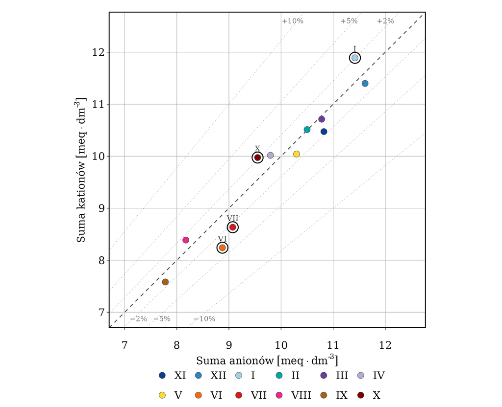

Porównanie sumy kationów i sumy anionów w kolejnych miesiącach roku

Każdy punkt to **jeden miesiąc**, w barwie z legendy: oś pozioma — suma **anionów**, pionowa — suma **kationów**, obie w meq·dm⁻³.

| Element ryciny | Co oznacza |
| --- | --- |
| prosta przerywana 45° | **bilans idealny**: obie sumy równe |
| linie kropkowane | błąd względny ±2%, ±5% i ±10% |
| punkt obwiedziony kółkiem | miesiąc poza progiem ±2%, podpisany liczbą rzymską |

Punkt **nad** prostą to przewaga kationów, **pod** nią — przewaga anionów.

To kontrola jakości, nie wynik merytoryczny

## Składniki biogenne

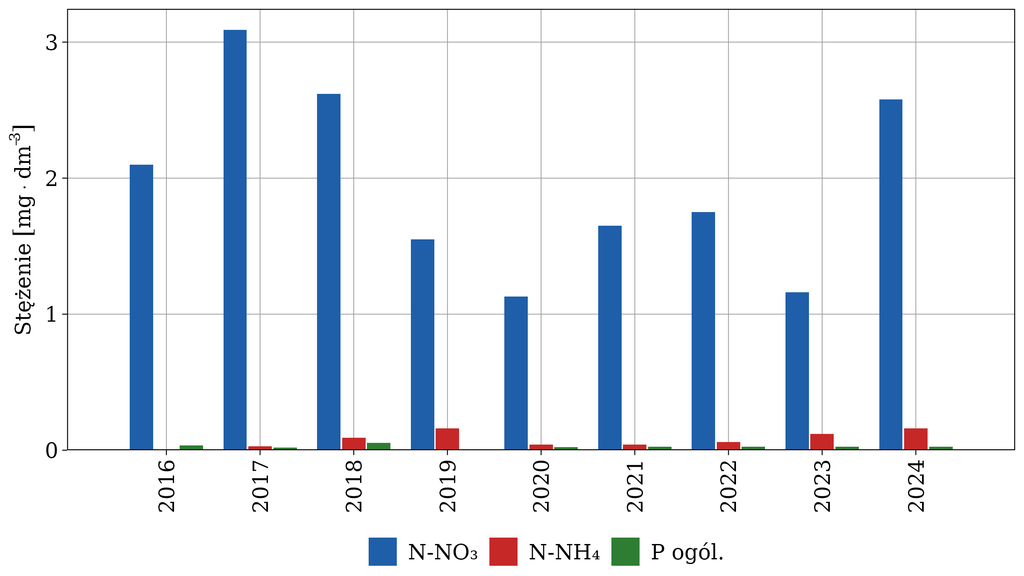

Średnie ważone stężenia składników biogennych w kolejnych latach

Trzy składniki: **azot azotanowy (N-NO₃)**, **azot amonowy (N-NH₄)** i **fosfor ogólny**. Słupki są ustawione obok siebie, grupa na rok.

Szukaj **kierunku zmian w kolejnych latach**, a nie pojedynczego roku.

**Brakujący słupek to nie zero.** Lata bez słupka fosforu to lata, dla których baza nie ma stężenia tego składnika — a nie lata, w których fosforu nie było.

Fosfor podano w mg·dm⁻³ wspólnie z pozostałymi, więc jego słupek bywa bardzo niski.

## Diagram Schoellera

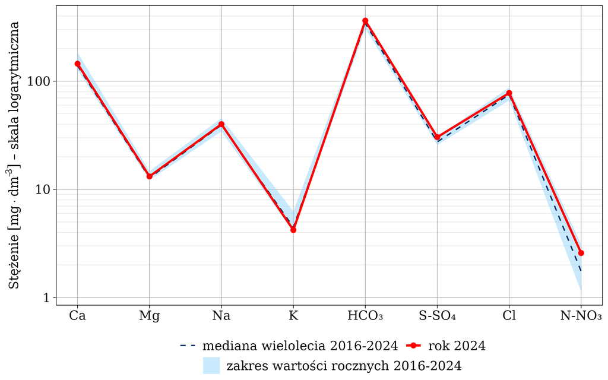

Rok hydrologiczny na tle wielolecia; skala pionowa logarytmiczna

Stężenia **ośmiu składników** połączone łamaną — te same, które stoją w tabeli 5.

| Element ryciny | Co oznacza |
| --- | --- |
| czerwona linia | rok analizowany |
| linia przerywana | **mediana** wielolecia |
| jasna wstęga | **zakres** wartości rocznych wielolecia |

Czytasz **odstępstwa**: składnik, przy którym czerwona linia odchodzi od przerywanej albo wychodzi poza wstęgę, to ten, którego stężenie odbiegło od typowego dla stacji.

**Skala logarytmiczna.** Ta sama odległość w pionie to ta sama **krotność**, a nie ta sama różnica: odcinek od 1 do 10 jest tak długi jak od 10 do 100.

## Diagram Schoellera — ujęcie miesięczne

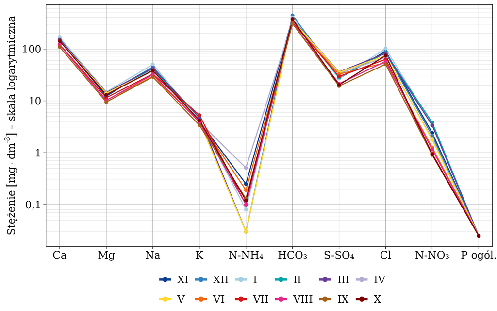

Zmienność miesięczna w roku hydrologicznym

To samo ujęcie, ale **jedna łamana na każdy miesiąc** — i dwa składniki więcej: **N-NH₄** oraz **fosfor ogólny**, przeliczony na mg·dm⁻³.

Rycina odpowiada na pytanie: **czy stężenia były w roku stabilne?**

- łamane **równoległe i blisko siebie** — stężenia wyrównane przez cały rok
- łamana **wyraźnie odstająca** — miesiąc, w którym coś się wydarzyło: roztopy, wezbranie, susza

Zestaw ją wtedy z rycinami 2 i 3 z części hydrologicznej

## Ładunki składników rozpuszczonych

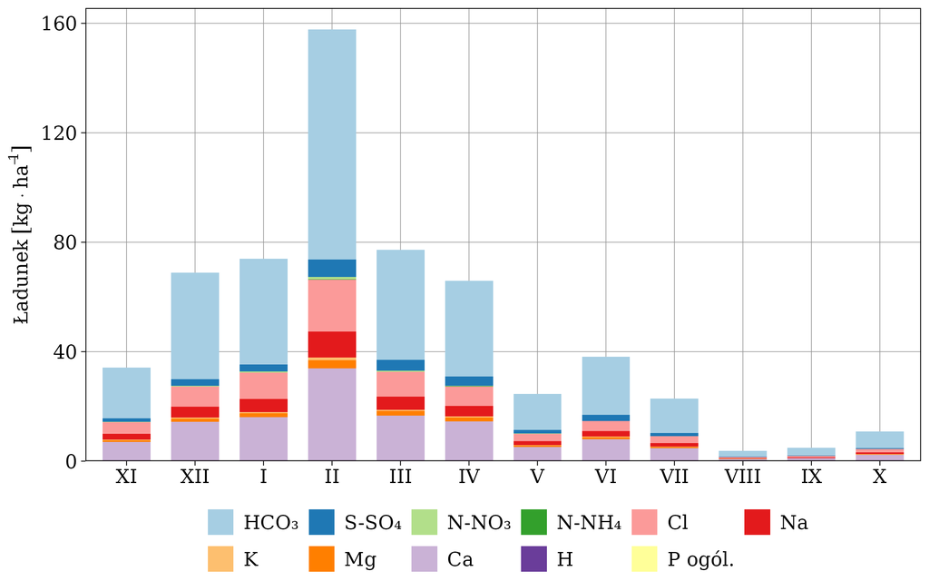

Miesięczny ładunek składników rozpuszczonych odprowadzany z odpływem rzecznym

Słupek skumulowany na każdy miesiąc: **wysokość całego słupka to ładunek miesięczny ogółem**, a warstwy pokazują udział składników.

**Wysoki ładunek nie znaczy wysokiego stężenia.** Ładunek zależy też od ilości wody, więc najwyższe słupki wypadają zwykle w miesiącach o największym odpływie — nawet gdy stężenia były wtedy niższe niż zwykle.

Największy ładunek odprowadzono w lutym, co odpowiada miesiącowi o najwyższym odpływie; udział wodorowęglanów przekraczał wtedy połowę ładunku miesięcznego.

## Wykres Tickela

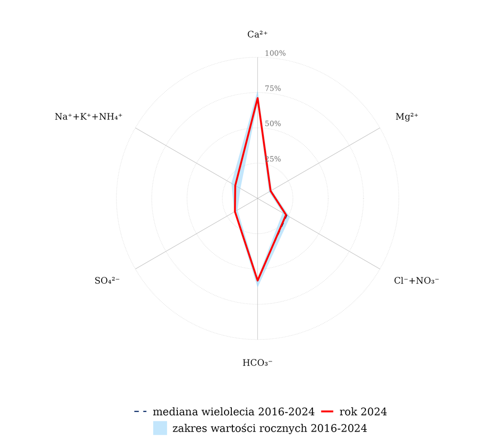

Udziały jonów w roku hydrologicznym na tle wielolecia

Sześć promieni z udziałami jonów w % meq: **Ca²⁺**, **Mg²⁺**, **Cl⁻+NO₃⁻**, **HCO₃⁻**, **SO₄²⁻**, **Na⁺+K⁺+NH₄⁺**.

| Element ryciny | Co oznacza |
| --- | --- |
| linia czerwona | rok analizowany |
| jasna wstęga | zakres wartości rocznych wielolecia |
| linia przerywana | mediana wielolecia |

Kationy zajmują górną połowę, aniony dolną. Udziały liczone **osobno w każdej z nich**, więc trójka promieni roku analizowanego domyka się do 100%.

Mediana wielolecia liczona jest osobno dla każdego promienia, więc jej trójka nie musi dać dokładnie 100% — jest tłem, a nie składem konkretnej wody.

## Gdzie szukać dalej

**Jak uruchomić narzędzie**  
Skrócona instrukcja programu (A1, H1, hydrochemia) oraz `INSTRUKCJA_KROK_PO_KROKU.pdf` w archiwum `A1.zip` / `H1.zip`.

**Co zawiera każda rycina i tabela**  
Rozdział *Jak czytać ryciny* w skróconej instrukcji swojego programu.

**Zasada wspólna dla wszystkich rycin**

Opisujesz **wzory i tendencje**, a nie pojedyncze wartości. Dokładne liczby są w tabelach raportu i w arkuszu `*_tabele.xlsx` – rycina ma pokazać, co z nich wynika.

Materiały zostały opracowane z wykorzystaniem Claude